# Análisis exploratorio de datos

#### Minería de Datos - Laboratorio 1

```python
import pandas as pd
import numpy as np
import matplotlib.pyplot as plt
import scipy.stats as sp
```

#### Importar un archivo de datos

```python
df = pd.read_csv("./Clasificacion.txt",sep="\t")
df.head()
```

|  | ID Caso | Clase Vino | Alcohol | Acido Malico | Cenizas | Alcalinidad Cenizas | Magnesio | Fenoles Totales | Flavanoides | Fenoles No Flavanoides | Protoantocianinas | Intensidad Color | Matiz | OD280_OD315 de lso vinos diluidos | Prolina |
| --- | --- | --- | --- | --- | --- | --- | --- | --- | --- | --- | --- | --- | --- | --- | --- |
| 0 | 1 | 1 | 14.23 | 1.71 | 2.43 | 15.6 | 127 | 2.80 | 3.06 | 0.28 | 2.29 | 5.64 | 1.04 | 3.92 | 1065 |
| 1 | 2 | 1 | 13.20 | 1.78 | 2.14 | 11.2 | 100 | 2.65 | 2.76 | 0.26 | 1.28 | 4.38 | 1.05 | 3.40 | 1050 |
| 2 | 3 | 1 | 13.16 | 2.36 | 2.67 | 18.6 | 101 | 2.80 | 3.24 | 0.30 | 2.81 | 5.68 | 1.03 | 3.17 | 1185 |
| 3 | 4 | 1 | 14.37 | 1.95 | 2.50 | 16.8 | 113 | 3.85 | 3.49 | 0.24 | 2.18 | 7.80 | 0.86 | 3.45 | 1480 |
| 4 | 5 | 1 | 13.24 | 2.59 | 2.87 | 21.0 | 118 | 2.80 | 2.69 | 0.39 | 1.82 | 4.32 | 1.04 | 2.93 | 735 |

### Calculo de estadísticas descriptivas

Previo a conocer el contexto de los datos, de que variables se componen la data y que representan, el siguiente paso sugerido es calcular las estadísticas descriptivas del conjunto de las variables que componen los datos para revisar su frecuencia, distribución completitud y hacerse una idea de ellos.

```python
# Cálculo de estadísticas descriptivas
print ('El máximo es:' + str(df.Cenizas.max()))
print ('El mínimo es:' + str(df.Cenizas.min()))
print ('La media es:' + str(round(df.Cenizas.mean(),2)))
print ('La desviación estandar es:' + str(round(df.Cenizas.std(),2)))
print ('La varianza es:' + str(round(df.Cenizas.var(),2)))
```

```
El máximo es:3.23
El mínimo es:1.36
La media es:2.37
La desviación estandar es:0.27
La varianza es:0.08
```

```python
#Obtenemos el promedio de cada columna del dataset
df.mean()
```

```
ID Caso                               90.000000
Clase Vino                             1.944134
Alcohol                               13.006927
Acido Malico                           2.346201
Cenizas                                2.368603
Alcalinidad Cenizas                   19.522905
Magnesio                              99.720670
Fenoles Totales                        2.293743
Flavanoides                            2.022179
Fenoles No Flavanoides                 0.362961
Protoantocianinas                      1.589553
Intensidad Color                       5.081229
Matiz                                  0.955508
OD280_OD315 de lso vinos diluidos      2.606034
Prolina                              745.849162
dtype: float64
```

```python
# Obitene los estadísticos de todas las columnas
df.describe()
```

|  | ID Caso | Clase Vino | Alcohol | Acido Malico | Cenizas | Alcalinidad Cenizas | Magnesio | Fenoles Totales | Flavanoides | Fenoles No Flavanoides | Protoantocianinas | Intensidad Color | Matiz | OD280_OD315 de lso vinos diluidos | Prolina |
| --- | --- | --- | --- | --- | --- | --- | --- | --- | --- | --- | --- | --- | --- | --- | --- |
| count | 179.000000 | 179.000000 | 179.000000 | 179.000000 | 179.000000 | 179.000000 | 179.000000 | 179.000000 | 179.000000 | 179.000000 | 179.000000 | 179.000000 | 179.000000 | 179.000000 | 179.000000 |
| mean | 90.000000 | 1.944134 | 13.006927 | 2.346201 | 2.368603 | 19.522905 | 99.720670 | 2.293743 | 2.022179 | 0.362961 | 1.589553 | 5.081229 | 0.955508 | 2.606034 | 745.849162 |
| std | 51.816986 | 0.776919 | 0.813932 | 1.121776 | 0.274993 | 3.351116 | 14.245053 | 0.624359 | 1.000557 | 0.124984 | 0.571033 | 2.332401 | 0.229403 | 0.712020 | 314.332206 |
| min | 1.000000 | 1.000000 | 11.030000 | 0.740000 | 1.360000 | 10.600000 | 70.000000 | 0.980000 | 0.340000 | 0.130000 | 0.410000 | 1.280000 | 0.480000 | 1.270000 | 278.000000 |
| 25% | 45.500000 | 1.000000 | 12.365000 | 1.605000 | 2.210000 | 17.200000 | 88.000000 | 1.745000 | 1.150000 | 0.270000 | 1.250000 | 3.230000 | 0.780000 | 1.925000 | 501.000000 |
| 50% | 90.000000 | 2.000000 | 13.050000 | 1.870000 | 2.360000 | 19.500000 | 98.000000 | 2.350000 | 2.130000 | 0.340000 | 1.550000 | 4.700000 | 0.960000 | 2.780000 | 672.000000 |
| 75% | 134.500000 | 3.000000 | 13.685000 | 3.110000 | 2.560000 | 21.500000 | 107.000000 | 2.800000 | 2.870000 | 0.445000 | 1.950000 | 6.225000 | 1.120000 | 3.170000 | 985.000000 |
| max | 179.000000 | 3.000000 | 14.830000 | 5.800000 | 3.230000 | 30.000000 | 162.000000 | 3.880000 | 5.080000 | 0.660000 | 3.580000 | 13.000000 | 1.710000 | 4.000000 | 1680.000000 |

```python
# Obtenemos el estadístico de la columna seleccionada
df["Clase Vino"].describe()
```

```
count    179.000000
mean       1.944134
std        0.776919
min        1.000000
25%        1.000000
50%        2.000000
75%        3.000000
max        3.000000
Name: Clase Vino, dtype: float64
```

```python
#Obtiene el tipo de dato, y la cantidad de registros de cada columna
df.info()
```

```
<class 'pandas.core.frame.DataFrame'>
RangeIndex: 179 entries, 0 to 178
Data columns (total 15 columns):
ID Caso                              179 non-null int64
Clase Vino                           179 non-null int64
Alcohol                              179 non-null float64
Acido Malico                         179 non-null float64
Cenizas                              179 non-null float64
Alcalinidad Cenizas                  179 non-null float64
Magnesio                             179 non-null int64
Fenoles Totales                      179 non-null float64
Flavanoides                          179 non-null float64
Fenoles No Flavanoides               179 non-null float64
Protoantocianinas                    179 non-null float64
Intensidad Color                     179 non-null float64
Matiz                                179 non-null float64
OD280_OD315 de lso vinos diluidos    179 non-null float64
Prolina                              179 non-null int64
dtypes: float64(11), int64(4)
memory usage: 21.1 KB
```

```python
# Obtemos los dos primeros registros del dataset
df.head(2)
```

|  | ID Caso | Clase Vino | Alcohol | Acido Malico | Cenizas | Alcalinidad Cenizas | Magnesio | Fenoles Totales | Flavanoides | Fenoles No Flavanoides | Protoantocianinas | Intensidad Color | Matiz | OD280_OD315 de lso vinos diluidos | Prolina |
| --- | --- | --- | --- | --- | --- | --- | --- | --- | --- | --- | --- | --- | --- | --- | --- |
| 0 | 1 | 1 | 14.23 | 1.71 | 2.43 | 15.6 | 127 | 2.80 | 3.06 | 0.28 | 2.29 | 5.64 | 1.04 | 3.92 | 1065 |
| 1 | 2 | 1 | 13.20 | 1.78 | 2.14 | 11.2 | 100 | 2.65 | 2.76 | 0.26 | 1.28 | 4.38 | 1.05 | 3.40 | 1050 |

```python
# Obtenemos el número total de registros en el dataset
len(df)
```

```
179
```

```python
#Obtenemos los últimos 5 registros del dataset
df.tail(5)
```

|  | ID Caso | Clase Vino | Alcohol | Acido Malico | Cenizas | Alcalinidad Cenizas | Magnesio | Fenoles Totales | Flavanoides | Fenoles No Flavanoides | Protoantocianinas | Intensidad Color | Matiz | OD280_OD315 de lso vinos diluidos | Prolina |
| --- | --- | --- | --- | --- | --- | --- | --- | --- | --- | --- | --- | --- | --- | --- | --- |
| 174 | 175 | 3 | 13.40 | 3.91 | 2.48 | 23.0 | 102 | 1.80 | 0.75 | 0.43 | 1.41 | 7.3 | 0.70 | 1.56 | 750 |
| 175 | 176 | 3 | 13.27 | 4.28 | 2.26 | 20.0 | 120 | 1.59 | 0.69 | 0.43 | 1.35 | 10.2 | 0.59 | 1.56 | 835 |
| 176 | 177 | 3 | 13.17 | 2.59 | 2.37 | 20.0 | 120 | 1.65 | 0.68 | 0.53 | 1.46 | 9.3 | 0.60 | 1.62 | 840 |
| 177 | 178 | 3 | 14.13 | 4.10 | 2.74 | 24.5 | 96 | 2.05 | 0.76 | 0.56 | 1.35 | 9.2 | 0.61 | 1.60 | 560 |
| 178 | 179 | 3 | 14.13 | 4.10 | 2.74 | 24.5 | 96 | 2.05 | 0.76 | 0.56 | 1.35 | 9.2 | 0.61 | 1.60 | 560 |

```python
# Obtiene el Nombre de las columnas
df.columns
```

```
Index(['ID Caso', 'Clase Vino', 'Alcohol', 'Acido Malico', 'Cenizas',
       'Alcalinidad Cenizas', 'Magnesio', 'Fenoles Totales', 'Flavanoides',
       'Fenoles No Flavanoides', 'Protoantocianinas', 'Intensidad Color',
       'Matiz', 'OD280_OD315 de lso vinos diluidos', 'Prolina'],
      dtype='object')
```

```python
# Obtiene los datos de la columna seleccionada
df["Alcohol"]
```

```
0      14.23
1      13.20
2      13.16
3      14.37
4      13.24
5      14.20
6      14.39
7      14.06
8      14.83
9      13.86
10     14.10
11     14.12
12     13.75
13     14.75
14     14.38
```

[output cut: 47 more lines]

```python
#Obtiene las 5 primeras filas de la columna seleccionada
df["Alcohol"][:5]
```

```
0    14.23
1    13.20
2    13.16
3    14.37
4    13.24
Name: Alcohol, dtype: float64
```

```python
#Obtiene el dato de la columna de la fila # 5
df["Alcohol"][5]
```

```
14.2
```

```python
#Obtiene los 5 primeras filas de las columnas indicadas
df[["Prolina", "Alcohol"]][:5]
```

|  | Prolina | Alcohol |
| --- | --- | --- |
| 0 | 1065 | 14.23 |
| 1 | 1050 | 13.20 |
| 2 | 1185 | 13.16 |
| 3 | 1480 | 14.37 |
| 4 | 735 | 13.24 |

```python
#Cuenta el número de registros agrupados por la columna seleccionada
df["Clase Vino"].value_counts()
```

```
2    71
1    59
3    49
Name: Clase Vino, dtype: int64
```

```python
#Para la matriz de correlaciones,o el porcentaje de relación entre las columnas seleccionadas con el algoritmo de perason:
df.corr(method="pearson")["Magnesio"]["Intensidad Color"]
```

```
0.1955369254608783
```

```python
# Obtiene las relaciones de cada variable del dataset con las demás, los porcentajes superiores a 0.7 son los más relacionados
df.loc[:,"Alcohol":"Prolina"].corr()
```

|  | Alcohol | Acido Malico | Cenizas | Alcalinidad Cenizas | Magnesio | Fenoles Totales | Flavanoides | Fenoles No Flavanoides | Protoantocianinas | Intensidad Color | Matiz | OD280_OD315 de lso vinos diluidos | Prolina |
| --- | --- | --- | --- | --- | --- | --- | --- | --- | --- | --- | --- | --- | --- |
| Alcohol | 1.000000 | 0.105425 | 0.219845 | -0.295056 | 0.267250 | 0.284375 | 0.224643 | -0.141707 | 0.132623 | 0.552375 | -0.082642 | 0.060532 | 0.635007 |
| Acido Malico | 0.105425 | 1.000000 | 0.173996 | 0.297829 | -0.056494 | -0.336150 | -0.417462 | 0.302822 | -0.222813 | 0.260670 | -0.567126 | -0.376565 | -0.195714 |
| Cenizas | 0.219845 | 0.173996 | 1.000000 | 0.449652 | 0.283058 | 0.125279 | 0.104342 | 0.195992 | 0.006396 | 0.268745 | -0.085295 | -0.006912 | 0.217740 |
| Alcalinidad Cenizas | -0.295056 | 0.297829 | 0.449652 | 1.000000 | -0.084988 | -0.322244 | -0.358185 | 0.370354 | -0.199516 | 0.033267 | -0.283130 | -0.285339 | -0.442371 |
| Magnesio | 0.267250 | -0.056494 | 0.283058 | -0.084988 | 1.000000 | 0.214844 | 0.196726 | -0.256766 | 0.236897 | 0.195537 | 0.057254 | 0.067703 | 0.393759 |
| Fenoles Totales | 0.284375 | -0.336150 | 0.125279 | -0.322244 | 0.214844 | 1.000000 | 0.863080 | -0.450050 | 0.612770 | -0.058520 | 0.434030 | 0.698808 | 0.498712 |
| Flavanoides | 0.224643 | -0.417462 | 0.104342 | -0.358185 | 0.196726 | 0.863080 | 1.000000 | -0.542939 | 0.652418 | -0.182670 | 0.548286 | 0.789285 | 0.495694 |
| Fenoles No Flavanoides | -0.141707 | 0.302822 | 0.195992 | 0.370354 | -0.256766 | -0.450050 | -0.542939 | 1.000000 | -0.366823 | 0.152584 | -0.272527 | -0.509482 | -0.314152 |
| Protoantocianinas | 0.132623 | -0.222813 | 0.006396 | -0.199516 | 0.236897 | 0.612770 | 0.652418 | -0.366823 | 1.000000 | -0.029199 | 0.297068 | 0.519224 | 0.331327 |
| Intensidad Color | 0.552375 | 0.260670 | 0.268745 | 0.033267 | 0.195537 | -0.058520 | -0.182670 | 0.152584 | -0.029199 | 1.000000 | -0.528897 | -0.436713 | 0.307095 |
| Matiz | -0.082642 | -0.567126 | -0.085295 | -0.283130 | 0.057254 | 0.434030 | 0.548286 | -0.272527 | 0.297068 | -0.528897 | 1.000000 | 0.570678 | 0.239464 |
| OD280_OD315 de lso vinos diluidos | 0.060532 | -0.376565 | -0.006912 | -0.285339 | 0.067703 | 0.698808 | 0.789285 | -0.509482 | 0.519224 | -0.436713 | 0.570678 | 1.000000 | 0.315405 |
| Prolina | 0.635007 | -0.195714 | 0.217740 | -0.442371 | 0.393759 | 0.498712 | 0.495694 | -0.314152 | 0.331327 | 0.307095 | 0.239464 | 0.315405 | 1.000000 |

# Medidas agrupadas

```python
#Obtiene los estadísticos indicados en la columna seleccionada
#a partir de la agrupación indicada
df.groupby(["Clase Vino"])["Alcalinidad Cenizas"].agg(["count","min","mean","max"])
```

| Clase Vino | count | min | mean | max |
| --- | --- | --- | --- | --- |
| 1 | 59 | 11.2 | 17.037288 | 25.0 |
| 2 | 71 | 10.6 | 20.238028 | 30.0 |
| 3 | 49 | 17.5 | 21.479592 | 27.0 |

```python
#Obtenemos el promedio desde y hasta la columna seleccionadas agrupado por la columna seleccionada
df.loc[:,"Clase Vino":"Prolina"].groupby("Clase Vino").mean()
```

| Clase Vino | Alcohol | Acido Malico | Cenizas | Alcalinidad Cenizas | Magnesio | Fenoles Totales | Flavanoides | Fenoles No Flavanoides | Protoantocianinas | Intensidad Color | Matiz | OD280_OD315 de lso vinos diluidos | Prolina |
| --- | --- | --- | --- | --- | --- | --- | --- | --- | --- | --- | --- | --- | --- |
| 1 | 13.744746 | 2.010678 | 2.455593 | 17.037288 | 106.338983 | 2.840169 | 2.982373 | 0.290000 | 1.899322 | 5.528305 | 1.062034 | 3.157797 | 1115.711864 |
| 2 | 12.278732 | 1.932676 | 2.244789 | 20.238028 | 94.549296 | 2.258873 | 2.080845 | 0.363662 | 1.630282 | 3.086620 | 1.056282 | 2.785352 | 519.507042 |
| 3 | 13.173673 | 3.349388 | 2.443265 | 21.479592 | 99.244898 | 1.686327 | 0.781020 | 0.449796 | 1.157551 | 7.433061 | 0.681224 | 1.681837 | 628.469388 |

```python
#matriz de correlaciones desde y hasta las columnas seleccionadas agrupadas por tipo de vino
df.loc[:,"Clase Vino":"Cenizas"].groupby("Clase Vino").corr()
```

| Clase Vino |  | Acido Malico | Alcohol | Cenizas |
| --- | --- | --- | --- | --- |
| 1 | Acido Malico | 1.000000 | -0.040513 | 0.026221 |
|  | Alcohol | -0.040513 | 1.000000 | -0.148595 |
|  | Cenizas | 0.026221 | -0.148595 | 1.000000 |
| 2 | Acido Malico | 1.000000 | -0.021362 | 0.148708 |
|  | Alcohol | -0.021362 | 1.000000 | -0.214851 |
|  | Cenizas | 0.148708 | -0.214851 | 1.000000 |
| 3 | Acido Malico | 1.000000 | 0.132197 | 0.040791 |
|  | Alcohol | 0.132197 | 1.000000 | 0.289670 |
|  | Cenizas | 0.040791 | 0.289670 | 1.000000 |

```python
# la matriz de relación muestra el nivel de interacción entre las diferentes variables.
```

# Gráficos

## Histograma

```python
#muestra la acumulación ó tendencia,
#la variabilidad o dispersión y la forma de la distribución de una variable dada.
```

### Frencuencia de porcentaje de alcohol

```python
df["Alcohol"].describe()
```

```
count    179.000000
mean      13.006927
std        0.813932
min       11.030000
25%       12.365000
50%       13.050000
75%       13.685000
max       14.830000
Name: Alcohol, dtype: float64
```

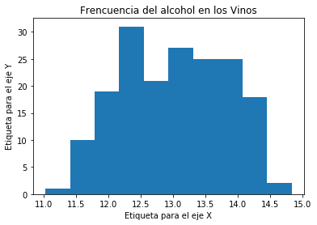

```python
plt.hist(df["Alcohol"])
plt.title("Frencuencia del alcohol en los Vinos")
plt.xlabel("Etiqueta para el eje X")
plt.ylabel("Etiqueta para el eje Y")
plt.show()
```

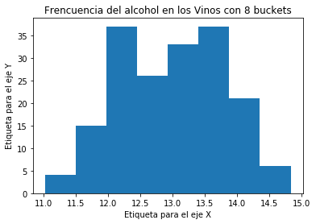

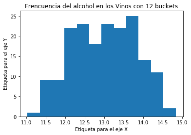

```python
# Cambiando el número de barras o contenedores
plt.hist(df["Alcohol"], bins=8)
plt.title("Frencuencia del alcohol en los Vinos con 8 buckets")
plt.xlabel("Etiqueta para el eje X")
plt.ylabel("Etiqueta para el eje Y")
plt.show()

plt.hist(df["Alcohol"], bins=12)
plt.title("Frencuencia del alcohol en los Vinos con 12 buckets")
plt.xlabel("Etiqueta para el eje X")
plt.ylabel("Etiqueta para el eje Y")
plt.show()
```

### Frecuencia de porcentaje de Magnesio

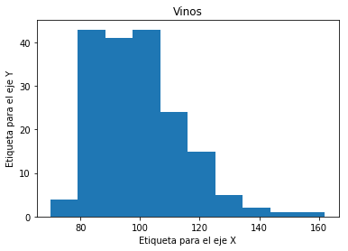

```python
plt.hist(df["Magnesio"])
plt.title("Vinos")
plt.xlabel("Etiqueta para el eje X")
plt.ylabel("Etiqueta para el eje Y")
plt.show()
```

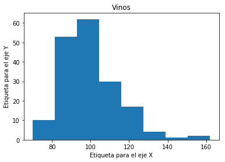

```python
plt.hist(df["Magnesio"], bins = 8)
plt.title("Vinos")
plt.xlabel("Etiqueta para el eje X")
plt.ylabel("Etiqueta para el eje Y")
plt.show()
```

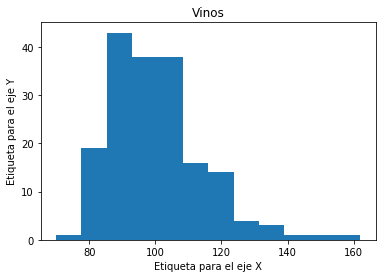

```python
plt.hist(df["Magnesio"], bins = 12)
plt.title("Vinos")
plt.xlabel("Etiqueta para el eje X")
plt.ylabel("Etiqueta para el eje Y")
plt.show()
```

## Boxplot

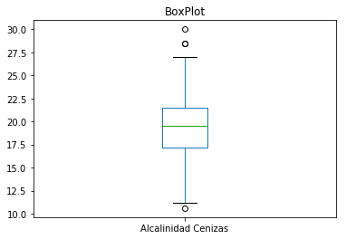

```python
# Analizar medidas de tendencia y dispersión
#epresentar gráficamente una serie de datos numéricos a través de sus cuartiles.
#De esta manera, el diagrama de caja muestra a simple vista la mediana y los cuartiles de los datos
#pudiendo también representar los valores atípicos de estos.
df["Alcalinidad Cenizas"].plot(kind="box",title="BoxPlot")
```

```python
# hay tres valores atípicos, dos por encima del 4 cuartil y uno por debajo del 1 cuartil
```

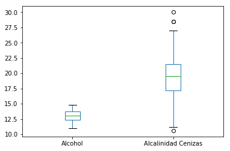

```python
# Graficar para varias variables simultáneamente
df.loc[:,["Alcohol","Alcalinidad Cenizas"]].plot.box()
# El alcohol tiene una desciación mucho menor hacia el primedio y no tiene valores atípicos
```

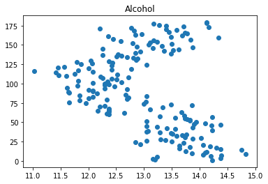

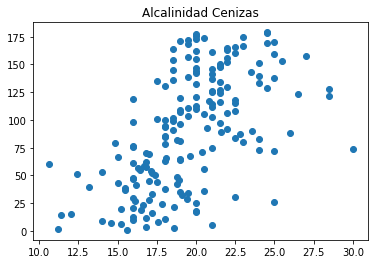

```python
# En efecto, las variables se encuentran más relacinadas entre 11 y 15
plt.scatter(df["Alcohol"],df["ID Caso"])
plt.title("Alcohol")
plt.show()
# Las variables se encuentran más dispersas, y hay dos valores atípicos
plt.scatter(df["Alcalinidad Cenizas"],df["ID Caso"])
plt.title("Alcalinidad Cenizas")
plt.show()
```

## Diagrama de dispersión

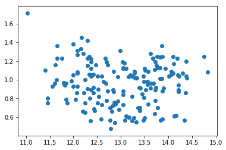

```python
#Permite ver la relación simultánea de variables continuas
plt.scatter(df["Alcohol"],df["Matiz"])
plt.show()
```

## Gráfico de barras

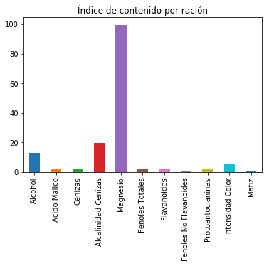

```python
# Permite comparar la relación de valores entre variables,
#en este caso, el promedio desde la columna "alcohol" hasta la columna "Matiz"
df.loc[:,"Alcohol":"Matiz"].mean().plot(kind="bar", title="Índice de contenido por ración")
```

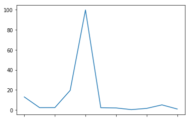

```python
# Con líneas
df.loc[:,"Alcohol":"Matiz"].mean().plot(kind="line")
```

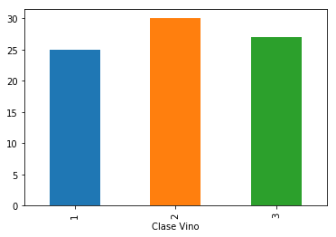

```python
#valor máximo para una variable entre las distintas clases de vino
df.groupby("Clase Vino")["Alcalinidad Cenizas"].max().plot(kind="bar")
```

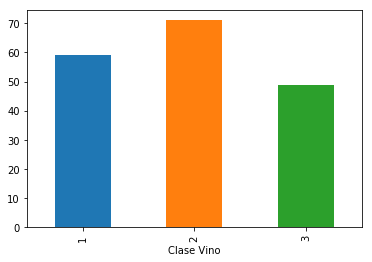

```python
#Distribución de la clase de vino en el dataset
df.groupby("Clase Vino")["Clase Vino"].count().plot(kind="bar")
```

## Diagramas de pie

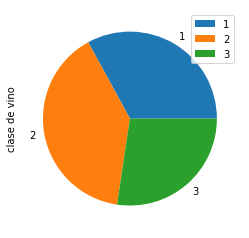

```python
#Visualizar los datos en forma circular
df.groupby("Clase Vino")["Clase Vino"].count().plot(kind="pie", label="clase de vino", legend="true")
```

```python
df.groupby("Clase Vino")["Clase Vino"].count()
```

```
Clase Vino
1    59
2    71
3    49
Name: Clase Vino, dtype: int64
```

## Tablas de confusión

```python
#Resume el numero de ocurrencias de cada valor para una variable dada.
pd.crosstab(index=df["Clase Vino"],columns="count")
```

| col_0 Clase Vino | count |
| --- | --- |
| 1 | 59 |
| 2 | 71 |
| 3 | 49 |

```python
for co in df.columns:
    print(co)
```

```
ID Caso
Clase Vino
Alcohol
Acido Malico
Cenizas
Alcalinidad Cenizas
Magnesio
Fenoles Totales
Flavanoides
Fenoles No Flavanoides
Protoantocianinas
Intensidad Color
Matiz
OD280_OD315 de lso vinos diluidos
Prolina
```

```python
#Muestra el número de ocurrencias del dato en cada valor
tcruzada = pd.crosstab(index=df["Clase Vino"], columns=df["Alcohol"])
tcruzada.index= ["Vino 1","Vino 2","Vino 3"] #Cambia el nombre de los índices de agrupación
tcruzada
```

| Alcohol | 11.03 | 11.41 | 11.45 | 11.46 | 11.56 | 11.61 | 11.62 | 11.64 | 11.65 | 11.66 | ... | 14.21 | 14.22 | 14.23 | 14.3 | 14.34 | 14.37 | 14.38 | 14.39 | 14.75 | 14.83 |
| --- | --- | --- | --- | --- | --- | --- | --- | --- | --- | --- | --- | --- | --- | --- | --- | --- | --- | --- | --- | --- | --- |
| Vino 1 | 0 | 0 | 0 | 0 | 0 | 0 | 0 | 0 | 0 | 0 | ... | 1 | 2 | 1 | 1 | 0 | 1 | 2 | 1 | 1 | 1 |
| Vino 2 | 1 | 1 | 1 | 1 | 1 | 1 | 1 | 1 | 1 | 1 | ... | 0 | 0 | 0 | 0 | 0 | 0 | 0 | 0 | 0 | 0 |
| Vino 3 | 0 | 0 | 0 | 0 | 0 | 0 | 0 | 0 | 0 | 0 | ... | 0 | 0 | 0 | 0 | 1 | 0 | 0 | 0 | 0 | 0 |

3 rows × 126 columns

# Análisis, Comprensión y preprocesamiento de los Datos

## Parte 1

Selecciones 5 variables y de acuerdo a los histogramas y las medidas vistas en clase (media, varianza, skew, kurtosis) indique si se trata de frecuencias unimodales, bimodales simétricas o asimétricas(desequilibradas), y su apreciación de la distribución de los datos de esa variable en el contexto vinos.

```python
# Hacemos una separación de los dataset por clase de vino
dfc1 = df[df["Clase Vino"] == 1]
dfc2 = df[df["Clase Vino"] == 2]
dfc3 = df[df["Clase Vino"] == 3]
```

Basados en el ínidice de correlación de los puntos anteriores, se optó por escoger las variables más correlacionadas en alguna de las clases de vino, para compararla se toman las tres clases de vino y la medida general

#### Alcalinidad Cenizas

La alcalinidad de las cenizas trata de la suma de los cationes de amonio que se encuentran mezclados en los ácidos orgánicos del vino. Es una variable de tipo Cuantitativo continuo, lo que podría interpretarse como el porcenje.

```
******* Alcalinidad Cenizas ********
Media =  19.52290502793296
varianza =  11.167240722823875
Desviación =  3.341742168813129
sknew =  0.20155959494723427
kurtosis =  0.9993166570687904
(array([ 3.,  2.,  1.,  2.,  6., 18., 15., 17., 23., 24., 18., 16., 11.,
        7.,  9.,  2.,  2.,  0.,  2.,  1.]), array([10.6 , 11.57, 12.54, 13.51, 14.48, 15.45, 16.42, 17.39, 18.36,
       19.33, 20.3 , 21.27, 22.24, 23.21, 24.18, 25.15, 26.12, 27.09,
       28.06, 29.03, 30.  ]), <a list of 20 Patch objects>)
```

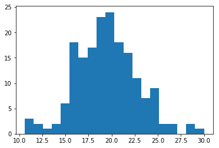

```python
print('******* Alcalinidad Cenizas ********')
print("Media = ", df["Alcalinidad Cenizas"].mean())
print("varianza = ", np.var(df["Alcalinidad Cenizas"]))
print("Desviación = ", np.std(df["Alcalinidad Cenizas"]))
print("sknew = ", sp.skew(df["Alcalinidad Cenizas"]))
print("kurtosis = ", sp.kurtosis(dfc1["Alcalinidad Cenizas"]))
print(plt.hist(df["Alcalinidad Cenizas"],bins=20))
```

Como se observa en el histograma, la función unimodal positiva (0,2) muestra una alta concentración de Alcalinidad de Cenizas fe forma general en los vinos, el promedio es 19.52 con una desviación de 3.3%.

```
******* Alcalinidad Cenizas Vino 1 ********
Media =  17.037288135593222
varianza =  6.373863832232119
Desviación =  2.524651229820095
sknew =  0.20061132209769655
kurtosis =  0.9993166570687904
(array([ 2.,  2.,  1.,  0.,  3.,  3.,  9.,  7., 10.,  5.,  2.,  6.,  4.,
        2.,  1.,  0.,  1.,  0.,  0.,  1.]), array([11.2 , 11.89, 12.58, 13.27, 13.96, 14.65, 15.34, 16.03, 16.72,
       17.41, 18.1 , 18.79, 19.48, 20.17, 20.86, 21.55, 22.24, 22.93,
       23.62, 24.31, 25.  ]), <a list of 20 Patch objects>)
```

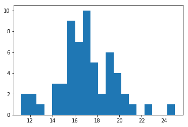

```python
print('******* Alcalinidad Cenizas Vino 1 ********')
print("Media = ", dfc1["Alcalinidad Cenizas"].mean())
print("varianza = ", np.var(dfc1["Alcalinidad Cenizas"]))
print("Desviación = ", np.std(dfc1["Alcalinidad Cenizas"]))
print("sknew = ", sp.skew(dfc1["Alcalinidad Cenizas"]))
print("kurtosis = ", sp.kurtosis(dfc1["Alcalinidad Cenizas"]))
print(plt.hist(dfc1["Alcalinidad Cenizas"],bins=20))
```

En el Vino clase 1 se observa una función unimodal positiva (0,2) con una kurtosis o grosor de curva de 0.99. Se observa una acumulación de Alcalinidad hacia el 17%, como lo marca el promedio, con una desviación estandar de 2,52%.

```
******* Alcalinidad Cenizas Vino 2 ********
Media =  20.238028169014086
varianza =  11.062920055544541
Desviación =  3.326096819929411
sknew =  0.421628487093137
kurtosis =  1.0535213097801348
(array([ 1.,  0.,  7., 12., 17., 18.,  9.,  3.,  1.,  3.]), array([10.6 , 12.54, 14.48, 16.42, 18.36, 20.3 , 22.24, 24.18, 26.12,
       28.06, 30.  ]), <a list of 10 Patch objects>)
```

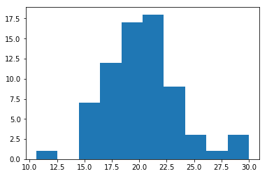

```python
print('******* Alcalinidad Cenizas Vino 2 ********')
print("Media = ", dfc2["Alcalinidad Cenizas"].mean())
print("varianza = ", np.var(dfc2["Alcalinidad Cenizas"]))
print("Desviación = ", np.std(dfc2["Alcalinidad Cenizas"]))
print("sknew = ", sp.skew(dfc2["Alcalinidad Cenizas"]))
print("kurtosis = ", sp.kurtosis(dfc2["Alcalinidad Cenizas"]))
print(plt.hist(dfc2["Alcalinidad Cenizas"]))
```

```
******* Alcalinidad Cenizas Vino 3 ********
Media =  21.479591836734695
varianza =  5.081216159933362
Desviación =  2.2541553096300535
sknew =  0.40088838747080563
kurtosis =  -0.7018016678984154
(array([1., 1., 4., 1., 4., 9., 1., 4., 4., 4., 2., 2., 1., 3., 3., 3., 1.,
       0., 0., 1.]), array([17.5  , 17.975, 18.45 , 18.925, 19.4  , 19.875, 20.35 , 20.825,
       21.3  , 21.775, 22.25 , 22.725, 23.2  , 23.675, 24.15 , 24.625,
       25.1  , 25.575, 26.05 , 26.525, 27.   ]), <a list of 20 Patch objects>)
```

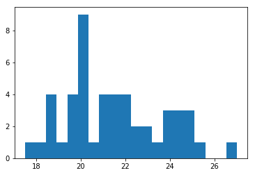

```python
print('******* Alcalinidad Cenizas Vino 3 ********')
print("Media = ", dfc3["Alcalinidad Cenizas"].mean())
print("varianza = ", np.var(dfc3["Alcalinidad Cenizas"]))
print("Desviación = ", np.std(dfc3["Alcalinidad Cenizas"]))
print("sknew = ", sp.skew(dfc3["Alcalinidad Cenizas"]))
print("kurtosis = ", sp.kurtosis(dfc3["Alcalinidad Cenizas"]))
print(plt.hist(dfc3["Alcalinidad Cenizas"], bins=20))
```

En el Vino clase 3 se observa una función unimodal positiva (0.4). El promedio de Alcalinidad se encuentra hacia los 21.47 con una desviación estandar de 2.25.

#### Conclusión sobre la alcalinidad

De las tres clases de vino, el dos es quien posee una más amplia concentración de Alcalinidad de Cenizas, que es la suma de cationes presentes en los ácidos del vino. El Vino 1 y el vino 3, por el contrario, tienen de forma más reducida el grado de alcalinidad. A continuación el el siguiente diagrama, se observa con mayor detalle la acumulación de alcalinidad por clase de vino.

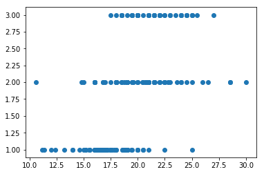

```python
plt.scatter(df["Alcalinidad Cenizas"],df["Clase Vino"])
```

#### Cenizas

Las cenizas son un conjunto de productos obtenidos como el resultado de la incineración de residuos de evaporación del vino, llevada a cabo esta incineración para la obtención de la totalidad de los cationes. Esta es una variable cuantitativa continua, lo que podría interpretarse como una medida de porcentaje.

```
******* Cenizas ********
Media =  2.3686033519553082
varianza =  0.07519860803345718
Desviación =  0.2742236460144478
sknew =  -0.18170224181554073
kurtosis =  1.0417989982637899
(array([ 1.,  3.,  7., 14., 43., 54., 31., 21.,  3.,  2.]), array([1.36 , 1.547, 1.734, 1.921, 2.108, 2.295, 2.482, 2.669, 2.856,
       3.043, 3.23 ]), <a list of 10 Patch objects>)
```

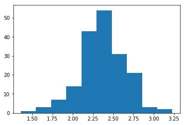

```python
print('******* Cenizas ********')
print("Media = ", df["Cenizas"].mean())
print("varianza = ", np.var(df["Cenizas"]))
print("Desviación = ", np.std(df["Cenizas"]))
print("sknew = ", sp.skew(df["Cenizas"]))
print("kurtosis = ", sp.kurtosis(df["Cenizas"]))
print(plt.hist(df["Cenizas"]))
```

```
******* Cenizas Clase 1 ********
Media =  2.455593220338984
varianza =  0.05072973283539215
Desviación =  0.22523261938580777
sknew =  0.5298835756421636
kurtosis =  0.7043188473937296
(array([ 7.,  5., 12., 13.,  9.,  9.,  2.,  1.,  0.,  1.]), array([2.04 , 2.158, 2.276, 2.394, 2.512, 2.63 , 2.748, 2.866, 2.984,
       3.102, 3.22 ]), <a list of 10 Patch objects>)
```

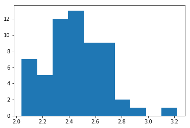

```python
print('******* Cenizas Clase 1 ********')
print("Media = ", dfc1["Cenizas"].mean())
print("varianza = ", np.var(dfc1["Cenizas"]))
print("Desviación = ", np.std(dfc1["Cenizas"]))
print("sknew = ", sp.skew(dfc1["Cenizas"]))
print("kurtosis = ", sp.kurtosis(dfc1["Cenizas"]))
print(plt.hist(dfc1["Cenizas"]))
```

Para el Vino de clase 1, se muestra una función unimodal positiva (0.5). El promedio para la clase 1 se encuentra sobre el 2.45c on una desviación de 0.22.

```
******* Cenizas Clase 2 ********
Media =  2.244788732394365
varianza =  0.09811791311247767
Desviación =  0.3132377900453227
sknew =  0.17184850315027558
kurtosis =  0.7800797821458438
(array([ 1.,  3.,  7., 10., 21., 14.,  8.,  5.,  1.,  1.]), array([1.36 , 1.547, 1.734, 1.921, 2.108, 2.295, 2.482, 2.669, 2.856,
       3.043, 3.23 ]), <a list of 10 Patch objects>)
```

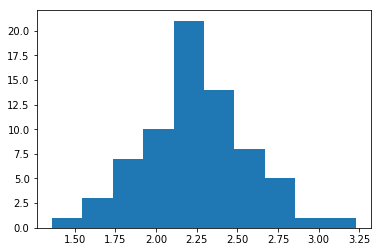

```python
print('******* Cenizas Clase 2 ********')
print("Media = ", dfc2["Cenizas"].mean())
print("varianza = ", np.var(dfc2["Cenizas"]))
print("Desviación = ", np.std(dfc2["Cenizas"]))
print("sknew = ", sp.skew(dfc2["Cenizas"]))
print("kurtosis = ", sp.kurtosis(dfc2["Cenizas"]))
print(plt.hist(dfc2["Cenizas"]))
```

```
******* Cenizas Clase 3 ********
Media =  2.4432653061224485
varianza =  0.03455260308204915
Desviación =  0.1858833050116367
sknew =  0.3174907199419924
kurtosis =  -0.9207055461949838
(array([ 2.,  5.,  9., 11.,  1.,  6.,  4.,  6.,  4.,  1.]), array([2.1  , 2.176, 2.252, 2.328, 2.404, 2.48 , 2.556, 2.632, 2.708,
       2.784, 2.86 ]), <a list of 10 Patch objects>)
```

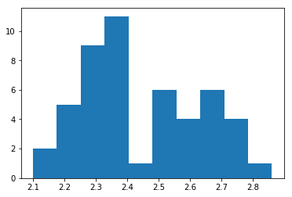

```python
print('******* Cenizas Clase 3 ********')
print("Media = ", dfc3["Cenizas"].mean())
print("varianza = ", np.var(dfc3["Cenizas"]))
print("Desviación = ", np.std(dfc3["Cenizas"]))
print("sknew = ", sp.skew(dfc3["Cenizas"]))
print("kurtosis = ", sp.kurtosis(dfc3["Cenizas"]))
print(plt.hist(dfc3["Cenizas"]))
```

#### Conclusión sobre la ceniza

Con respecto a la variable anterior, se puede decir que la cantidad de cenizas es más relevante en el sabor del vino que la alcalinidad, definiendo esta última como la acumulación de cationes resultantes de la mezcla, mientras que la ceniza en si muestra el grado de evaporación de los ingredientes en el proceso de preparación. Lo que se observa con más detalle en la siguiente gráfica:

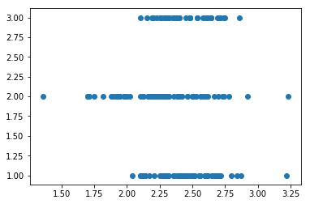

```python
plt.scatter(df["Cenizas"], df["Clase Vino"])
```

#### Alcohol

El alchohol del vino depende del que produzca su fermentación. El máximo grado de alcohol que suelen tener los vinos es de 15 grados, a excepción de los vinos de Jerez y de Oporto, que como vinos licorosos, generososos o fortalecidos tienen una graduación más elevada.

```
******* Alcohol ********
Media =  13.00692737430167
varianza =  0.6587844137199215
Desviación =  0.8116553540265237
sknew =  -0.058637293968574894
kurtosis =  -0.8738442242026108
(array([ 1., 10., 19., 31., 21., 27., 25., 25., 18.,  2.]), array([11.03, 11.41, 11.79, 12.17, 12.55, 12.93, 13.31, 13.69, 14.07,
       14.45, 14.83]), <a list of 10 Patch objects>)
```

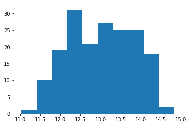

```python
print('******* Alcohol ********')
print("Media = ", df["Alcohol"].mean())
print("varianza = ", np.var(df["Alcohol"]))
print("Desviación = ", np.std(df["Alcohol"]))
print("sknew = ", sp.skew(df["Alcohol"]))
print("kurtosis = ", sp.kurtosis(df["Alcohol"]))
print(plt.hist(df["Alcohol"]))
```

De forma general, en las tres clases de vino se observa un contenido de alcohol muy variante sin ser un factor diferenciador entre uno y otro. Aunque se muestra un promedio de 13, hay una gran desviación de 0.8 indicando que el grado de alcohol es muy diverso y poco desicivo entre uno 1 otro. La función unimodal es negativa con una inclinación hacia la izquierda de -0.05.

```
******* Alcohol Clase 1 ********
Media =  13.744745762711865
varianza =  0.20994018960068944
Desviación =  0.4581923063525723
sknew =  0.06923898186233954
kurtosis =  -0.5967909626181376
(array([ 2.,  9.,  5.,  8., 11.,  6., 11.,  5.,  0.,  2.]), array([12.85 , 13.048, 13.246, 13.444, 13.642, 13.84 , 14.038, 14.236,
       14.434, 14.632, 14.83 ]), <a list of 10 Patch objects>)
```

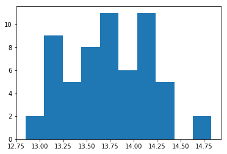

```python
print('******* Alcohol Clase 1 ********')
print("Media = ", dfc1["Alcohol"].mean())
print("varianza = ", np.var(dfc1["Alcohol"]))
print("Desviación = ", np.std(dfc1["Alcohol"]))
print("sknew = ", sp.skew(dfc1["Alcohol"]))
print("kurtosis = ", sp.kurtosis(dfc1["Alcohol"]))
print(plt.hist(dfc1["Alcohol"]))
```

De la misma forma que la descripción general, en el Vino clase uno no se percibe una importancia relevante de alchohol en su preparación pues los registros sobre esta clase y en esta varible tienen una dispersión de 0.45. La función descrita es casi bimodal, con una inlcinación positiva de 0.07

```
******* Alcohol Clase 2 ********
Media =  12.278732394366198
varianza =  0.2853293790914501
Desviación =  0.534162315304487
sknew =  0.567868111960227
kurtosis =  0.6141811846879026
(array([ 1.,  4., 13., 12., 21., 10.,  2.,  4.,  2.,  2.]), array([11.03 , 11.313, 11.596, 11.879, 12.162, 12.445, 12.728, 13.011,
       13.294, 13.577, 13.86 ]), <a list of 10 Patch objects>)
```

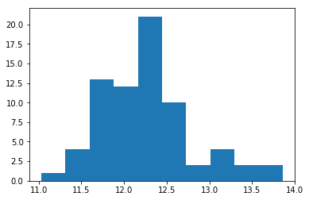

```python
print('******* Alcohol Clase 2 ********')
print("Media = ", dfc2["Alcohol"].mean())
print("varianza = ", np.var(dfc2["Alcohol"]))
print("Desviación = ", np.std(dfc2["Alcohol"]))
print("sknew = ", sp.skew(dfc2["Alcohol"]))
print("kurtosis = ", sp.kurtosis(dfc2["Alcohol"]))
print(plt.hist(dfc2["Alcohol"]))
```

```
******* Alcohol Clase 3 ********
Media =  13.173673469387753
varianza =  0.2887334443981676
Desviación =  0.5373392265582028
sknew =  0.14507160407994793
kurtosis =  -0.7290966099985621
(array([4., 5., 6., 6., 6., 7., 6., 5., 0., 4.]), array([12.2  , 12.414, 12.628, 12.842, 13.056, 13.27 , 13.484, 13.698,
       13.912, 14.126, 14.34 ]), <a list of 10 Patch objects>)
```

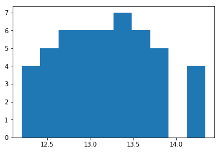

```python
print('******* Alcohol Clase 3 ********')
print("Media = ", dfc3["Alcohol"].mean())
print("varianza = ", np.var(dfc3["Alcohol"]))
print("Desviación = ", np.std(dfc3["Alcohol"]))
print("sknew = ", sp.skew(dfc3["Alcohol"]))
print("kurtosis = ", sp.kurtosis(dfc3["Alcohol"]))
print(plt.hist(dfc3["Alcohol"]))
```

En el vino de clase 3, al igual que en el uno, no se observa una concentración de registros en cuanto al nivel de alcohol, los datos están mas dispersos (0.53) con respectoa a la media que es de 13.17.

#### Conclusión sobre el alcohol

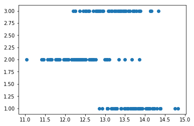

```python
plt.scatter(df["Alcohol"], df["Clase Vino"])
```

```
******* Magnesio ********
Media =  99.72067039106145
varianza =  201.78789675727955
Desviación =  14.20520667773896
sknew =  1.0956504732726644
kurtosis =  2.0435456692033416
(array([ 4., 43., 41., 43., 24., 15.,  5.,  2.,  1.,  1.]), array([ 70. ,  79.2,  88.4,  97.6, 106.8, 116. , 125.2, 134.4, 143.6,
       152.8, 162. ]), <a list of 10 Patch objects>)
```

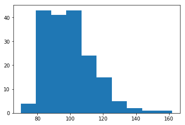

```python
print('******* Magnesio ********')
print("Media = ", df["Magnesio"].mean())
print("varianza = ", np.var(df["Magnesio"]))
print("Desviación = ", np.std(df["Magnesio"]))
print("sknew = ", sp.skew(df["Magnesio"]))
print("kurtosis = ", sp.kurtosis(df["Magnesio"]))
print(plt.hist(df["Magnesio"]))
```

En forma general, la cantidad de magnesio en la muestra, tiene un promedio de 99,7 con una desviación de 14.2. La función mostrada para la muestra es unimodal positiva con una inclinación de 1.09 y un grosor de 2.04.

```
******* Magnesio Clase 1********
Media =  106.33898305084746
varianza =  108.35966676242458
Desviación =  10.409594937480737
sknew =  0.48083727648064734
kurtosis =  -0.5433460015698639
(array([ 5.,  8., 10.,  9.,  7.,  5.,  8.,  2.,  3.,  2.]), array([ 89. ,  93.3,  97.6, 101.9, 106.2, 110.5, 114.8, 119.1, 123.4,
       127.7, 132. ]), <a list of 10 Patch objects>)
```

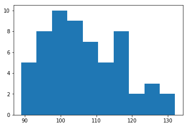

```python
print('******* Magnesio Clase 1********')
print("Media = ", dfc1["Magnesio"].mean())
print("varianza = ", np.var(dfc1["Magnesio"]))
print("Desviación = ", np.std(dfc1["Magnesio"]))
print("sknew = ", sp.skew(dfc1["Magnesio"]))
print("kurtosis = ", sp.kurtosis(dfc1["Magnesio"]))
print(plt.hist(dfc1["Magnesio"]))
```

Para el vino de clase 1, se muestra una dispersión mayor en el contenido de magnesio, los vinos de esta clase cuentan entre 90 y 131 mg de magnesio, resaltando una media de 106 con una desviación de 10.4. La función es unimodal con una desviación de 0.5.

```
******* Magnesio Clase 2********
Media =  94.54929577464789
varianza =  276.7264431660386
Desviación =  16.635096728484587
sknew =  2.068766308330599
kurtosis =  4.670458404091595
(array([ 4., 35., 10., 12.,  4.,  1.,  1.,  2.,  1.,  1.]), array([ 70. ,  79.2,  88.4,  97.6, 106.8, 116. , 125.2, 134.4, 143.6,
       152.8, 162. ]), <a list of 10 Patch objects>)
```

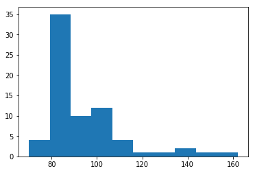

```python
print('******* Magnesio Clase 2********')
print("Media = ", dfc2["Magnesio"].mean())
print("varianza = ", np.var(dfc2["Magnesio"]))
print("Desviación = ", np.std(dfc2["Magnesio"]))
print("sknew = ", sp.skew(dfc2["Magnesio"]))
print("kurtosis = ", sp.kurtosis(dfc2["Magnesio"]))
print(plt.hist(dfc2["Magnesio"]))
```

A diferencia de la clase anterior, en los vinos de clase 2, existe una concentración mayor de mg de magnesio, aunque se encuentran desde los 70 hasta los 160, sobresaliendo una media de 94.55 y una desviación de 16. Claramente es una desviación positiva de 2.06

```
******* Magnesio Clase 3********
Media =  99.24489795918367
varianza =  113.98084131611832
Desviación =  10.676181026758506
sknew =  0.5464957464973637
kurtosis =  -0.5633341011787278
(array([ 1.,  7.,  8., 10.,  4.,  5.,  4.,  5.,  1.,  4.]), array([ 80. ,  84.3,  88.6,  92.9,  97.2, 101.5, 105.8, 110.1, 114.4,
       118.7, 123. ]), <a list of 10 Patch objects>)
```

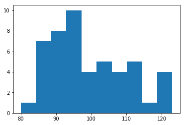

```python
print('******* Magnesio Clase 3********')
print("Media = ", dfc3["Magnesio"].mean())
print("varianza = ", np.var(dfc3["Magnesio"]))
print("Desviación = ", np.std(dfc3["Magnesio"]))
print("sknew = ", sp.skew(dfc3["Magnesio"]))
print("kurtosis = ", sp.kurtosis(dfc3["Magnesio"]))
print(plt.hist(dfc3["Magnesio"]))
```

#### Conclusión

[figure not shown]

```python
plt.scatter(df["Alcohol"], df["Clase Vino"])
```

### Intensidad Color

La intensidad de color de un vino hace referencia al grado en que la luz lo puede atravesar, al grado de opacidad del vino, cuando se observa el centro de la elipse que forma el vino en una copa inclinada.

```
******* Intensidad Color ********
Media =  5.081229044692739
varianza =  5.409704580845796
Desviación =  2.325877163748291
sknew =  0.8426439704843415
kurtosis =  0.2609649250665993
(array([16., 42., 32., 38., 17., 13., 11.,  6.,  3.,  1.]), array([ 1.28 ,  2.452,  3.624,  4.796,  5.968,  7.14 ,  8.312,  9.484,
       10.656, 11.828, 13.   ]), <a list of 10 Patch objects>)
```

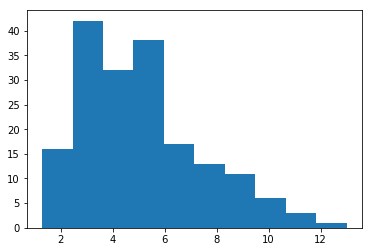

```python
#Intensidad Color
print('******* Intensidad Color ********')
print("Media = ", df["Intensidad Color"].mean())
print("varianza = ", np.var(df["Intensidad Color"]))
print("Desviación = ", np.std(df["Intensidad Color"]))
print("sknew = ", sp.skew(df["Intensidad Color"]))
print("kurtosis = ", sp.kurtosis(df["Intensidad Color"]))
print(plt.hist(df["Intensidad Color"]))
```

```
******* Intensidad Color Vino 1********
Media =  5.528305084745763
varianza =  1.5080615340419419
Desviación =  1.2280315688295402
sknew =  0.5749398979172918
kurtosis =  0.01631563579778339
(array([ 7.,  8., 10., 10.,  9.,  4.,  6.,  3.,  0.,  2.]), array([3.52 , 4.058, 4.596, 5.134, 5.672, 6.21 , 6.748, 7.286, 7.824,
       8.362, 8.9  ]), <a list of 10 Patch objects>)
```

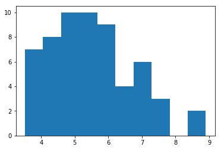

```python
print('******* Intensidad Color Vino 1********')
print("Media = ", dfc1["Intensidad Color"].mean())
print("varianza = ", np.var(dfc1["Intensidad Color"]))
print("Desviación = ", np.std(dfc1["Intensidad Color"]))
print("sknew = ", sp.skew(dfc1["Intensidad Color"]))
print("kurtosis = ", sp.kurtosis(dfc1["Intensidad Color"]))
print(plt.hist(dfc1["Intensidad Color"]))
```

Para el vino 1, la intensidad de color está entre 3 y 8, con un promedio de 5.5 y una desviación de 1.2.

```
******* Intensidad Color Vino 2********
Media =  3.08661971830986
varianza =  0.8434449117238643
Desviación =  0.918392569506017
sknew =  1.0177366365997242
kurtosis =  1.142659869202645
(array([ 2., 10., 14., 17., 13.,  6.,  2.,  4.,  1.,  2.]), array([1.28 , 1.752, 2.224, 2.696, 3.168, 3.64 , 4.112, 4.584, 5.056,
       5.528, 6.   ]), <a list of 10 Patch objects>)
```

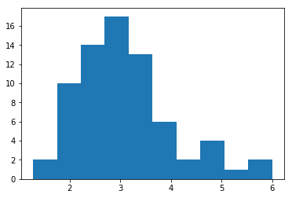

```python
print('******* Intensidad Color Vino 2********')
print("Media = ", dfc2["Intensidad Color"].mean())
print("varianza = ", np.var(dfc2["Intensidad Color"]))
print("Desviación = ", np.std(dfc2["Intensidad Color"]))
print("sknew = ", sp.skew(dfc2["Intensidad Color"]))
print("kurtosis = ", sp.kurtosis(dfc2["Intensidad Color"]))
print(plt.hist(dfc2["Intensidad Color"]))
```

Para el vino de clase 2, la intensidad de color está entre 1 y 6. El promedio mostrado por la función es de 3,08 y una desviación de 0.9. La función es unimodal 1.02

```
******* Intensidad Color Vino 3********
Media =  7.433061204081633
varianza =  5.187519099641835
Desviación =  2.2776125876983193
sknew =  0.2510725826044246
kurtosis =  -0.8476976039002846
(array([ 6., 10.,  3.,  5.,  7.,  7.,  5.,  4.,  1.,  1.]), array([ 3.85 ,  4.765,  5.68 ,  6.595,  7.51 ,  8.425,  9.34 , 10.255,
       11.17 , 12.085, 13.   ]), <a list of 10 Patch objects>)
```

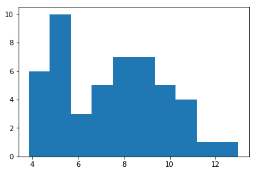

```python
print('******* Intensidad Color Vino 3********')
print("Media = ", dfc3["Intensidad Color"].mean())
print("varianza = ", np.var(dfc3["Intensidad Color"]))
print("Desviación = ", np.std(dfc3["Intensidad Color"]))
print("sknew = ", sp.skew(dfc3["Intensidad Color"]))
print("kurtosis = ", sp.kurtosis(dfc3["Intensidad Color"]))
print(plt.hist(dfc3["Intensidad Color"]))
```

#### Conclusión

De los tres vinos, el 3 es el más oscuro. Su nivel de color es más intenso, lo que puede darse como resultado de la combinación de ingredientes.

# Parte 2

A partir de matrices de correlación y scatterplot indique su análisis (correlaciones fuertes principalmente)

```python
#matriz de correlaciones por tipo de vino
df.loc[:,"Clase Vino":"Prolina"].groupby("Clase Vino").corr()
```

| Clase Vino |  | Acido Malico | Alcalinidad Cenizas | Alcohol | Cenizas | Fenoles No Flavanoides | Fenoles Totales | Flavanoides | Intensidad Color | Magnesio | Matiz | OD280_OD315 de lso vinos diluidos | Prolina | Protoantocianinas |
| --- | --- | --- | --- | --- | --- | --- | --- | --- | --- | --- | --- | --- | --- | --- |
| 1 | Acido Malico | 1.000000 | 0.060031 | -0.040513 | 0.026221 | -0.089366 | -0.083514 | -0.191278 | -0.257587 | 0.079317 | -0.419981 | 0.173244 | -0.372629 | -0.080798 |
|  | Alcalinidad Cenizas | 0.060031 | 1.000000 | -0.318367 | 0.549330 | 0.302262 | -0.222999 | -0.287103 | -0.210951 | 0.238337 | 0.092980 | -0.117704 | -0.122436 | -0.173628 |
|  | Alcohol | -0.040513 | -0.318367 | 1.000000 | -0.148595 | 0.015659 | 0.420687 | 0.414904 | 0.408291 | 0.159361 | 0.080020 | 0.069818 | 0.360646 | 0.307571 |
|  | Cenizas | 0.026221 | 0.549330 | -0.148595 | 1.000000 | 0.465901 | 0.004802 | -0.070454 | -0.124220 | 0.382549 | 0.239214 | -0.081593 | -0.029525 | -0.145471 |
|  | Fenoles No Flavanoides | -0.089366 | 0.302262 | 0.015659 | 0.465901 | 1.000000 | -0.016992 | -0.089538 | -0.152460 | 0.237248 | 0.411831 | -0.323488 | -0.015333 | -0.144535 |
|  | Fenoles Totales | -0.083514 | -0.222999 | 0.420687 | 0.004802 | -0.016992 | 1.000000 | 0.803784 | 0.650086 | 0.307241 | -0.224330 | 0.053165 | 0.294994 | 0.373601 |
|  | Flavanoides | -0.191278 | -0.287103 | 0.414904 | -0.070454 | -0.089538 | 0.803784 | 1.000000 | 0.741560 | 0.123332 | 0.007863 | -0.088529 | 0.380446 | 0.548624 |
|  | Intensidad Color | -0.257587 | -0.210951 | 0.408291 | -0.124220 | -0.152460 | 0.650086 | 0.741560 | 1.000000 | 0.184661 | 0.028228 | -0.186899 | 0.588770 | 0.424696 |
|  | Magnesio | 0.079317 | 0.238337 | 0.159361 | 0.382549 | 0.237248 | 0.307241 | 0.123332 | 0.184661 | 1.000000 | -0.111386 | 0.120651 | -0.147912 | -0.059042 |
|  | Matiz | -0.419981 | 0.092980 | 0.080020 | 0.239214 | 0.411831 | -0.224330 | 0.007863 | 0.028228 | -0.111386 | 1.000000 | -0.310659 | 0.353366 | 0.103937 |
|  | OD280_OD315 de lso vinos diluidos | 0.173244 | -0.117704 | 0.069818 | -0.081593 | -0.323488 | 0.053165 | -0.088529 | -0.186899 | 0.120651 | -0.310659 | 1.000000 | -0.348169 | 0.003106 |
|  | Prolina | -0.372629 | -0.122436 | 0.360646 | -0.029525 | -0.015333 | 0.294994 | 0.380446 | 0.588770 | -0.147912 | 0.353366 | -0.348169 | 1.000000 | 0.142166 |
|  | Protoantocianinas | -0.080798 | -0.173628 | 0.307571 | -0.145471 | -0.144535 | 0.373601 | 0.548624 | 0.424696 | -0.059042 | 0.103937 | 0.003106 | 0.142166 | 1.000000 |
| 2 | Acido Malico | 1.000000 | 0.237923 | -0.021362 | 0.148708 | 0.127605 | 0.039441 | 0.111932 | -0.203258 | -0.076788 | -0.407986 | 0.157838 | -0.224214 | 0.210541 |
|  | Alcalinidad Cenizas | 0.237923 | 1.000000 | -0.056282 | 0.695264 | 0.182617 | 0.127942 | 0.311356 | -0.085862 | 0.003263 | -0.076825 | 0.382078 | -0.014507 | 0.108838 |
|  | Alcohol | -0.021362 | -0.056282 | 1.000000 | -0.214851 | -0.068159 | -0.046321 | -0.038247 | 0.269789 | -0.029911 | -0.002038 | -0.130313 | 0.043174 | -0.189617 |
|  | Cenizas | 0.148708 | 0.695264 | -0.214851 | 1.000000 | 0.299757 | 0.112146 | 0.314937 | 0.060247 | 0.129130 | -0.031244 | 0.160590 | 0.041959 | 0.042955 |
|  | Fenoles No Flavanoides | 0.127605 | 0.182617 | -0.068159 | 0.299757 | 1.000000 | -0.424746 | -0.235258 | 0.018537 | -0.194138 | -0.033717 | -0.413119 | -0.152688 | -0.321587 |
|  | Fenoles Totales | 0.039441 | 0.127942 | -0.046321 | 0.112146 | -0.424746 | 1.000000 | 0.770999 | 0.169072 | 0.070085 | 0.039685 | 0.484666 | 0.016927 | 0.382578 |
|  | Flavanoides | 0.111932 | 0.311356 | -0.038247 | 0.314937 | -0.235258 | 0.770999 | 1.000000 | 0.378563 | 0.001688 | -0.029381 | 0.579593 | -0.122608 | 0.499311 |
|  | Intensidad Color | -0.203258 | -0.085862 | 0.269789 | 0.060247 | 0.018537 | 0.169072 | 0.378563 | 1.000000 | 0.043931 | -0.026077 | -0.117099 | 0.102366 | -0.073763 |
|  | Magnesio | -0.076788 | 0.003263 | -0.029911 | 0.129130 | -0.194138 | 0.070085 | 0.001688 | 0.043931 | 1.000000 | 0.124831 | -0.076189 | 0.499593 | 0.297787 |
|  | Matiz | -0.407986 | -0.076825 | -0.002038 | -0.031244 | -0.033717 | 0.039685 | -0.029381 | -0.026077 | 0.124831 | 1.000000 | -0.052373 | 0.114460 | -0.054409 |
|  | OD280_OD315 de lso vinos diluidos | 0.157838 | 0.382078 | -0.130313 | 0.160590 | -0.413119 | 0.484666 | 0.579593 | -0.117099 | -0.076189 | -0.052373 | 1.000000 | -0.110812 | 0.385771 |
|  | Prolina | -0.224214 | -0.014507 | 0.043174 | 0.041959 | -0.152688 | 0.016927 | -0.122608 | 0.102366 | 0.499593 | 0.114460 | -0.110812 | 1.000000 | 0.124417 |
|  | Protoantocianinas | 0.210541 | 0.108838 | -0.189617 | 0.042955 | -0.321587 | 0.382578 | 0.499311 | -0.073763 | 0.297787 | -0.054409 | 0.385771 | 0.124417 | 1.000000 |
| 3 | Acido Malico | 1.000000 | 0.102580 | 0.132197 | 0.040791 | 0.153949 | -0.143099 | -0.281181 | -0.149031 | -0.178351 | 0.069727 | 0.002683 | -0.005952 | -0.214767 |
|  | Alcalinidad Cenizas | 0.102580 | 1.000000 | 0.248752 | 0.768735 | 0.008476 | 0.382379 | 0.264269 | 0.178252 | 0.147762 | 0.009349 | 0.032304 | -0.113336 | 0.271190 |
|  | Alcohol | 0.132197 | 0.248752 | 1.000000 | 0.289670 | 0.069891 | 0.239192 | 0.070818 | 0.365255 | -0.092508 | -0.056326 | 0.116216 | -0.108169 | 0.380828 |
|  | Cenizas | 0.040791 | 0.768735 | 0.289670 | 1.000000 | 0.010237 | 0.486916 | 0.267206 | 0.146820 | 0.195295 | 0.153835 | 0.208914 | -0.162911 | 0.204113 |
|  | Fenoles No Flavanoides | 0.153949 | 0.008476 | 0.069891 | 0.010237 | 1.000000 | 0.339238 | -0.630452 | 0.040399 | -0.506631 | 0.139320 | 0.297999 | 0.188398 | 0.178966 |
|  | Fenoles Totales | -0.143099 | 0.382379 | 0.239192 | 0.486916 | 0.339238 | 1.000000 | 0.234686 | 0.346686 | -0.045668 | -0.039277 | 0.191455 | 0.029321 | 0.621897 |
|  | Flavanoides | -0.281181 | 0.264269 | 0.070818 | 0.267206 | -0.630452 | 0.234686 | 1.000000 | 0.363405 | 0.568663 | -0.290881 | -0.428784 | -0.244571 | 0.406274 |
|  | Intensidad Color | -0.149031 | 0.178252 | 0.365255 | 0.146820 | 0.040399 | 0.346686 | 0.363405 | 1.000000 | 0.098526 | -0.572910 | -0.107216 | 0.109401 | 0.686716 |
|  | Magnesio | -0.178351 | 0.147762 | -0.092508 | 0.195295 | -0.506631 | -0.045668 | 0.568663 | 0.098526 | 1.000000 | 0.008582 | -0.220649 | 0.192808 | 0.149972 |
|  | Matiz | 0.069727 | 0.009349 | -0.056326 | 0.153835 | 0.139320 | -0.039277 | -0.290881 | -0.572910 | 0.008582 | 1.000000 | 0.366428 | 0.010322 | -0.425358 |
|  | OD280_OD315 de lso vinos diluidos | 0.002683 | 0.032304 | 0.116216 | 0.208914 | 0.297999 | 0.191455 | -0.428784 | -0.107216 | -0.220649 | 0.366428 | 1.000000 | 0.198525 | -0.131267 |
|  | Prolina | -0.005952 | -0.113336 | -0.108169 | -0.162911 | 0.188398 | 0.029321 | -0.244571 | 0.109401 | 0.192808 | 0.010322 | 0.198525 | 1.000000 | 0.188217 |
|  | Protoantocianinas | -0.214767 | 0.271190 | 0.380828 | 0.204113 | 0.178966 | 0.621897 | 0.406274 | 0.686716 | 0.149972 | -0.425358 | -0.131267 | 0.188217 | 1.000000 |

### Relación Flavanoides - Intensidad de Color

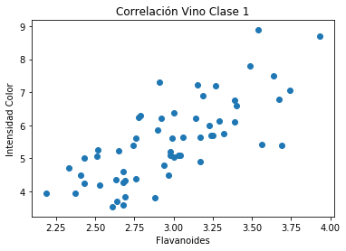

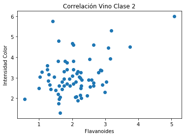

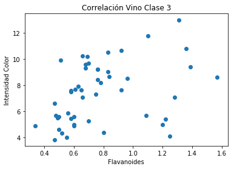

```python
#Obtenemos la dispersión para los vinos de clase 1
plt.scatter(dfc1["Flavanoides"],dfc1["Intensidad Color"])
plt.title("Correlación Vino Clase 1")
plt.xlabel("Flavanoides")
plt.ylabel("Intensidad Color")
plt.show()

plt.scatter(dfc2["Flavanoides"],dfc2["Intensidad Color"])
plt.title("Correlación Vino Clase 2")
plt.xlabel("Flavanoides")
plt.ylabel("Intensidad Color")
plt.show()

plt.scatter(dfc3["Flavanoides"],dfc3["Intensidad Color"])
plt.title("Correlación Vino Clase 3")
plt.xlabel("Flavanoides")
plt.ylabel("Intensidad Color")
plt.show()
```

#### Conclusión

En el vino de clase 1, existe una mayor relación entre los flavanoides y la intensidad de color. El vino 1 y 3 pueden ser los más oscuros y parte de esa intensidad de color puede darse gracias a los flavanoides.

### Relación Flavanoides - Fenoles Totales

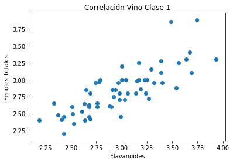

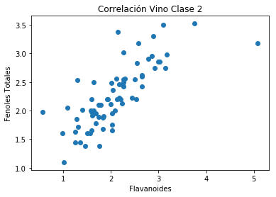

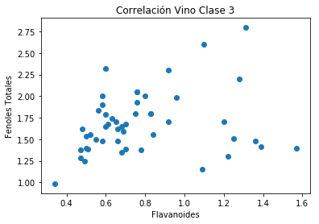

```python
plt.scatter(dfc1["Flavanoides"],dfc1["Fenoles Totales"])
plt.title("Correlación Vino Clase 1")
plt.xlabel("Flavanoides")
plt.ylabel("Fenoles Totales")
plt.show()

plt.scatter(dfc2["Flavanoides"],dfc2["Fenoles Totales"])
plt.title("Correlación Vino Clase 2")
plt.xlabel("Flavanoides")
plt.ylabel("Fenoles Totales")
plt.show()

plt.scatter(dfc3["Flavanoides"],dfc3["Fenoles Totales"])
plt.title("Correlación Vino Clase 3")
plt.xlabel("Flavanoides")
plt.ylabel("Fenoles Totales")
plt.show()
```

#### Conclusión

Tanto en el vino de clase 1 y el de clase 2, se observa una mayor relación entre los Flavaniodes y los Fenoles totales.

### Relación Cenizas- Alcalinidad Cenizas

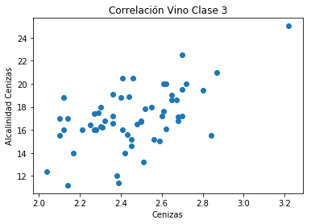

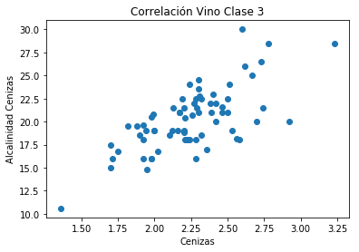

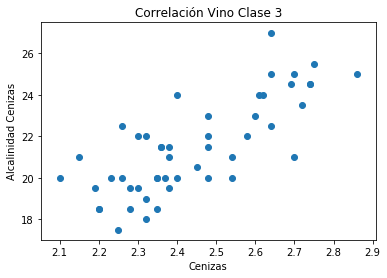

```python
#Obtenemos la dispersión para los vinos de clase 1,
plt.scatter(dfc1["Cenizas"],dfc1["Alcalinidad Cenizas"])
plt.title("Correlación Vino Clase 3")
plt.xlabel("Cenizas")
plt.ylabel("Alcalinidad Cenizas")
plt.show()

#Obtenemos la dispersión para los vinos de clase 2
plt.scatter(dfc2["Cenizas"],dfc2["Alcalinidad Cenizas"])
plt.title("Correlación Vino Clase 3")
plt.xlabel("Cenizas")
plt.ylabel("Alcalinidad Cenizas")
plt.show()

#Obtenemos la dispersión para los vinos de clase 3
plt.scatter(dfc3["Cenizas"],dfc3["Alcalinidad Cenizas"])
plt.title("Correlación Vino Clase 3")
plt.xlabel("Cenizas")
plt.ylabel("Alcalinidad Cenizas")
plt.show()
```

#### Conclusión

Se muestra una relación mayor de cenizas y alcalinidad cenizas en los vinos de clase 2 y 3.

### Identificación de Ruido

```python
#Utilizamos la siguiente función para identificar los niveles de ruido en el data set
def detect_outlier(data_1):
    outliers=[]
    threshold=3
    mean_1 = np.mean(data_1)
    std_1 =np.std(data_1)


    for y in data_1:
        z_score= (y - mean_1)/std_1
        if np.abs(z_score) > threshold:
            outliers.append(y)
    return outliers
```

Para conocer las variables con mayor ruido, utilizamos un ciclo e invocamos la función por cada dataset

```python
for column in df.columns:
    print(column + ' -> '+ str(detect_outlier(df[column])))
```

```
ID Caso -> []
Clase Vino -> []
Alcohol -> []
Acido Malico -> [5.8]
Cenizas -> [3.22, 1.36, 3.23]
Alcalinidad Cenizas -> [30.0]
Magnesio -> [151, 162]
Fenoles Totales -> []
Flavanoides -> [5.08]
Fenoles No Flavanoides -> []
Protoantocianinas -> [3.58]
Intensidad Color -> [13.0]
Matiz -> [1.71]
OD280_OD315 de lso vinos diluidos -> []
Prolina -> []
```

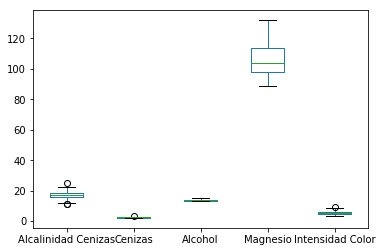

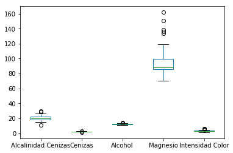

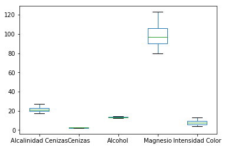

```python
# Conayuda del boxplot también podemos identificar las variables con mator ruido
dfc1.loc[:,["Alcalinidad Cenizas", "Cenizas", "Alcohol", "Magnesio", "Intensidad Color"]].plot.box()
dfc2.loc[:,["Alcalinidad Cenizas", "Cenizas", "Alcohol", "Magnesio", "Intensidad Color"]].plot.box()
dfc3.loc[:,["Alcalinidad Cenizas", "Cenizas", "Alcohol", "Magnesio", "Intensidad Color"]].plot.box()
```

### Indique que variables tienen valores faltantes

Recordamos que la cantidad de registros en el dataset es de 179, para buscar los valores faltantes usamos la siguiente función.

```python
df.info()
```

```
<class 'pandas.core.frame.DataFrame'>
RangeIndex: 179 entries, 0 to 178
Data columns (total 15 columns):
ID Caso                              179 non-null int64
Clase Vino                           179 non-null int64
Alcohol                              179 non-null float64
Acido Malico                         179 non-null float64
Cenizas                              179 non-null float64
Alcalinidad Cenizas                  179 non-null float64
Magnesio                             179 non-null int64
Fenoles Totales                      179 non-null float64
Flavanoides                          179 non-null float64
Fenoles No Flavanoides               179 non-null float64
Protoantocianinas                    179 non-null float64
Intensidad Color                     179 non-null float64
Matiz                                179 non-null float64
OD280_OD315 de lso vinos diluidos    179 non-null float64
Prolina                              179 non-null int64
dtypes: float64(11), int64(4)
memory usage: 21.1 KB
```

Como se observa, el data set no tiene datos faltantes.

## Operaciones básicas de datos

### Discretizar variables (bining)

Se eligen las variables: Magnesio, Alcalinidad Cenizas e Intensidad Color pues, como se observó en el punto anterior, presentan mayor nivel de outliers. A continuación se describe cada uno:

```python
# Discretice 3 variables usando le método cut. Explique porqué discretizó estas variables.
df["Magnesio_3bin"] = pd.cut(df.loc[:,"Magnesio"], 3, labels=["good", "medium", "bad"])
df.groupby("Magnesio_3bin").size()
```

```
Magnesio_3bin
good      101
medium     72
bad         6
dtype: int64
```

```python
df["Magnesio_cuantiles"] = pd.qcut(df.loc[:,"Magnesio"], [0, .25, .5, .75, 1], labels=["min", "cu1", "cu2", "cu3"])
df.groupby("Magnesio_cuantiles").size()
```

```
Magnesio_cuantiles
min    47
cu1    50
cu2    38
cu3    44
dtype: int64
```

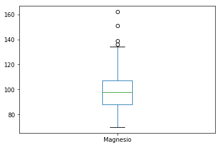

```python
df.loc[:,["Magnesio"]].plot.box()
```

```python
df["Alcalinidad_3bin"] = pd.cut(df.loc[:,"Alcalinidad Cenizas"], 3, labels=["good", "medium", "bad"])
df.groupby("Alcalinidad_3bin").size()
```

```
Alcalinidad_3bin
good       43
medium    114
bad        22
dtype: int64
```

```python
df["Alcalinidad_cuantiles"] = pd.qcut(df.loc[:,"Alcalinidad Cenizas"], [0, .25, .5, .75, 1], labels=["min", "cu1", "cu2", "cu3"])
df.groupby("Alcalinidad_cuantiles").size()
```

```
Alcalinidad_cuantiles
min    47
cu1    48
cu2    42
cu3    42
dtype: int64
```

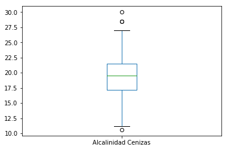

```python
df.loc[:,["Alcalinidad Cenizas"]].plot.box()
```

```python
df["Color_3bin"] = pd.cut(df.loc[:,"Intensidad Color"], 3, labels=["good", "medium", "bad"])
df.groupby("Color_3bin").size()
```

```
Color_3bin
good      103
medium     62
bad        14
dtype: int64
```

```python
df["Color_cuantiles"] = pd.qcut(df.loc[:,"Intensidad Color"], [0, .25, .5, .75, 1], labels=["min", "cu1", "cu2", "cu3"])
df.groupby("Color_cuantiles").size()
```

```
Color_cuantiles
min    45
cu1    45
cu2    44
cu3    45
dtype: int64
```

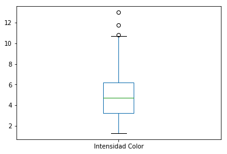

```python
df.loc[:,["Intensidad Color"]].plot.box()
```

#### Conclisón

Las variables seleccionadas muestran un ruido mayor por fuera de los cuartiles superiores.

### Contar los missing

Puede con las funciones isna y notna identificar y contar los registros nulos en una fila. Si no aplica la función suma es decir solo con pd.isna(df2['one']) enlistara los vacios con del dataset para la columna indicada

```python
for column in df.columns:
    print("El número de vacios en la columna "+column+" es: " + str(sum(pd.isna(df[column]))))
```

```
El número de vacios en la columna ID Caso es: 0
El número de vacios en la columna Clase Vino es: 0
El número de vacios en la columna Alcohol es: 0
El número de vacios en la columna Acido Malico es: 0
El número de vacios en la columna Cenizas es: 0
El número de vacios en la columna Alcalinidad Cenizas es: 0
El número de vacios en la columna Magnesio es: 0
El número de vacios en la columna Fenoles Totales es: 0
El número de vacios en la columna Flavanoides es: 0
El número de vacios en la columna Fenoles No Flavanoides es: 0
El número de vacios en la columna Protoantocianinas es: 0
El número de vacios en la columna Intensidad Color es: 0
El número de vacios en la columna Matiz es: 0
El número de vacios en la columna OD280_OD315 de lso vinos diluidos es: 0
El número de vacios en la columna Prolina es: 0
El número de vacios en la columna Magnesio_3bin es: 0
El número de vacios en la columna Magnesio_cuantiles es: 0
El número de vacios en la columna Alcalinidad_3bin es: 0
El número de vacios en la columna Alcalinidad_cuantiles es: 0
El número de vacios en la columna Color_3bin es: 0
El número de vacios en la columna Color_cuantiles es: 0
```

#### Conclusión

El data set no tiene valores null

### Normalizar una variable

Normalizar una variable continua es redimensionarla en medida de desviaciones estándar conocidas como valores Z por la tabla de puntajes Z de la distribución normal, proceso que se hace con la siguiente formula

```python
df["Alcohol_normalized"] =(df["Alcohol"] - df["Alcohol"].mean())/df["Alcohol"].std()
df.loc[:,["Alcohol", "Alcohol_normalized"]].head(5)
```

|  | Alcohol | Alcohol_normalized |
| --- | --- | --- |
| 0 | 14.23 | 1.502672 |
| 1 | 13.20 | 0.237210 |
| 2 | 13.16 | 0.188066 |
| 3 | 14.37 | 1.674676 |
| 4 | 13.24 | 0.286354 |

### Identificar valores atípicos

```python
df["Alcohol_outlier"] = np.where((df["Alcohol"] > (df["Alcohol"].mean()) + (2*df["Alcohol"].std())) |
                                    (df["Alcohol"] > (df["Alcohol"].mean()) - (2*df["Alcohol"].std())), 'yes', 'no')
```

```python
df[df["Alcohol_outlier"] == "yes"].head()
```

[output not shown]

```python
print((df["Alcohol"].mean()) - (2*df["Alcohol"].std()))
```

```
11.379063191082375
```

### Ahora que ya se han valores atípicos, escriba una rutina para suavizar/corregir dichos valores, en una nueva columna, llamada Alcohol_sav.

Para suavizar los valores atípicos reemplazamos estos valores invirtiendo los datos de la encuación que los detecto

```python
df["Alcohol_sav"] = np.where((df["Alcohol"] > (df["Alcohol"].mean()) + (2*df["Alcohol"].std())) |
                                    (df["Alcohol"] > (df["Alcohol"].mean()) - (2*df["Alcohol"].std())),
                                 ((df["Alcohol"].mean()) - (2*df["Alcohol"].std())),
                                ((df["Alcohol"].mean()) + (2*df["Alcohol"].std())))
```

```python
df.head()
```

[output not shown]

# Parte final

## Teniendo en cuenta los gráficos generados y las medidas tomadas al dataset Clasificación.csv , podría lanzar alguna hipótesis inicial que discrimine las distintas clase de vino?

Cada clase de vino tiene una preparación diferente. La mezcla de sus ingredientes hace que cada vino posea un sabor y una coloración diferente. De su mezcla, resaltan el magnesio y la Intensidad del Color como principales diferenciadores entre clases, seguidos por el la Alcalinidad de Cenizas, y las cenizas, cuyos promedios de concentración varían por cada mezcla. Por el contrario, el nivel de alcohol en las tres clases de vinos es casi similar.